# Life Expectancy

# Introduction

This app was developed as a final project for the Developing Data Products module of the Data Science Specialization by Johns Hopkins University on [Coursera.org](https://www.coursera.org).

The app was built using [Shiny](https://shiny.rstudio.com/) in [RStudio](https://www.rstudio.com/).

The interactive app takes does the following:  
1. Takes user selection for 1 or 2 countries/regions and other options.  
2. Uses [ggplot2](http://ggplot2.org/) to plot change in life expectancy for the selected country.  
3. Displays tables of minimum, maximum, first, last, average, and overall changes in life expectancy.

# The Data

The data the app uses comes from [worldbank.org](http://data.worldbank.org/indicator/SP.DYN.LE00.IN). The dataset contains life expectancy estimates for 264 countries and geographic regions from 1960 to 2014. Here is a small sample of the dataset:

```
   Country.Name    X1960    X1985    X2014
1         Aruba 65.56937 73.09798 75.45110
28       Brazil 54.20546 63.56256 74.40188
34       Canada 71.13317 76.30341 81.95661
56      Denmark 72.17659 74.42756 80.54878
```

# Sample App Usage

Here the user has selected Ukraine and Turkey as the countries to compare, and has checked the boxes to display min/max points and the world average line.

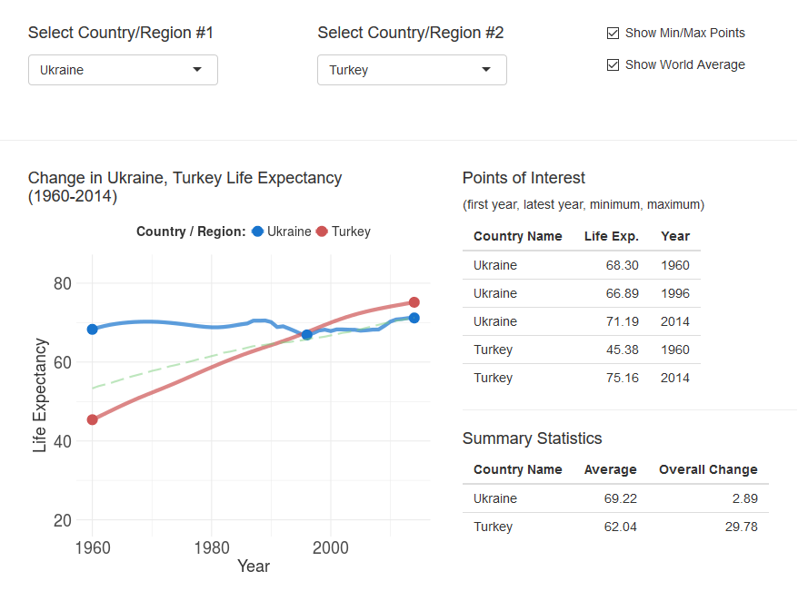

# Try It For Yourself!

Interested in trying the app for yourself? Click the following link to run the app on the ShinyApps server.

### [Life Expectancy App](https://fentontaylor.shinyapps.io/finalproject)

If you would like to view the source code for the app or this presentation, you can check out the following GitHub repos.  
- [ui.R and server.R files for the shiny app](https://github.com/fentontaylor/DevelopingDataProducts/tree/gh-pages/FinalProject)  
- [RPresentation document](https://github.com/fentontaylor/DevelopingDataProducts/tree/gh-pages/Presentation)